# R Notebook

```r
#nejake kniznice
library(dplyr)
library(tidyverse)
library(data.table)
library(corrplot)
library(RColorBrewer)
library(rcompanion)
library(lawstat)
library(moments)
library(forcats)
library(car)
library(ggpubr)
```

## Dáta

V tejto sekcii bude opísaný základný zdroj dát + postup, akým sme získali náš unikátny dataset - bolo potrebné vykonať viacero krokov, ktoré zahŕňali spájanie viacerých datasetov, elimináciu niektorých atribútov, deduplikáciu a na záver vytváranie úplne nových relevantných atribútov na základe hodnôt niektorých atribútov pôvodného datasetu.

### Tabuľka game

Tabuľka obsahuje základné dáta jednotlivých zápasov. Neobsahuje však detailné informácie o tímoch alebo tímových štatistikách konkrétneho zápasu. Taktiež neobsahuje čitateľné identifikátory tímov (t.j. ich názvy, obsahuje iba ID) Pomocou atribútov game_id, away_team_id a home_team_id však dokážeme namapovať iné tabuľky tak, aby sme dostali jeden dataset so všetkými pre nás relevantnými hodnotami.

```r
#setwd(dir)
path <- ('data/game.csv')
game <- fread(path)
head(game)
```

| game_id | season | type | date_time_GMT | away_team_id | home_team_id | away_goals | home_goals | outcome | home_rink_side_start | venue | venue_link | venue_time_zone_id | venue_time_zone_offset | venue_time_zone_tz |
| --- | --- | --- | --- | --- | --- | --- | --- | --- | --- | --- | --- | --- | --- | --- |
| 2016020045 | 20162017 | R | 2016-10-19 00:30:00 | 4 | 16 | 4 | 7 | home win REG | right | United Center | /api/v1/venues/null | America/Chicago | -5 | CDT |
| 2017020812 | 20172018 | R | 2018-02-07 00:00:00 | 24 | 7 | 4 | 3 | away win OT | left | KeyBank Center | /api/v1/venues/null | America/New_York | -4 | EDT |
| 2015020314 | 20152016 | R | 2015-11-24 01:00:00 | 21 | 52 | 4 | 1 | away win REG | right | MTS Centre | /api/v1/venues/null | America/Winnipeg | -5 | CDT |
| 2015020849 | 20152016 | R | 2016-02-17 00:00:00 | 52 | 12 | 1 | 2 | home win REG | right | PNC Arena | /api/v1/venues/null | America/New_York | -4 | EDT |
| 2017020586 | 20172018 | R | 2017-12-30 03:00:00 | 20 | 24 | 1 | 2 | home win REG | left | Honda Center | /api/v1/venues/null | America/Los_Angeles | -7 | PDT |
| 2016020610 | 20162017 | R | 2017-01-10 00:30:00 | 15 | 8 | 4 | 1 | away win REG | right | Centre Bell | /api/v1/venues/null | America/Montreal | -4 | EDT |

Niektoré atribúty sú z pohľadu štatistiky nezaujímavé a teda ich môžeme odstrániť pred spájaním tabuliek. Napríklad údaje o časovej zóne, alebo identifikátory štadiónov a pododobne. Pri týchto atribútoch predpokladáme, že pre naše riešenie zaujímavé žiadnym spôsobom nebudú - samozrejme, využitie by sa určite nájsť dalo, no aj vzhľadom na predpokladaný počet atribútov nemáme potrebu tieto atribúty v datasete ponechať.

```r
game <- subset(game, select=-c(venue_link,venue_time_zone_id, venue_time_zone_offset, venue_time_zone_tz))
head(game)
```

| game_id | season | type | date_time_GMT | away_team_id | home_team_id | away_goals | home_goals | outcome | home_rink_side_start | venue |
| --- | --- | --- | --- | --- | --- | --- | --- | --- | --- | --- |
| 2016020045 | 20162017 | R | 2016-10-19 00:30:00 | 4 | 16 | 4 | 7 | home win REG | right | United Center |
| 2017020812 | 20172018 | R | 2018-02-07 00:00:00 | 24 | 7 | 4 | 3 | away win OT | left | KeyBank Center |
| 2015020314 | 20152016 | R | 2015-11-24 01:00:00 | 21 | 52 | 4 | 1 | away win REG | right | MTS Centre |
| 2015020849 | 20152016 | R | 2016-02-17 00:00:00 | 52 | 12 | 1 | 2 | home win REG | right | PNC Arena |
| 2017020586 | 20172018 | R | 2017-12-30 03:00:00 | 20 | 24 | 1 | 2 | home win REG | left | Honda Center |
| 2016020610 | 20162017 | R | 2017-01-10 00:30:00 | 15 | 8 | 4 | 1 | away win REG | right | Centre Bell |

```r
dim(game)
```

```
[1] 26305    11
```

```r
dim(game[game$season==20192020,])
```

```
[1] 2425   11
```

```r
dim(subset(game, season==20192020 & type=='P'))
```

```
[1] 231  11
```

Prvotnou analýzou sme zistili, že v minulej sezóne sa odohralo približne 2500 zápasov, z čoho bolo +-10 percent (231 zápasov) v playoff. Percentuálny pomer zápasov regulárnej a vyraďovacej časti nie je vhodný pre rozdelenie na trénovací a testovací dataset (tam je odporúčaný pomer 70:30, resp. 80:20). Náš prvotný predpoklad, že môžeme dataset trénovať na regulárnej sezóne a následne testovať na zápasoch play-off teda nebude ideálny - vhodnejší bude možno prístup rozdelenia podľa sezón, kedy na zápasoch starších sezón model natrénujeme a testovať ho budeme na novšej sezóne.

Počet hier v minulej sezóne bol omnoho vyšší ako je zvykom, tak sme skontrolovali existenciu duplikátnych záznamov v tabuľke. Z nasledujúceho výpisu sme odhalili 2570 duplikátov v celej tabuľke.

```r
game[duplicated(game)]
```

| game_id | season | type | date_time_GMT | away_team_id | home_team_id | away_goals | home_goals | outcome | home_rink_side_start | venue |
| --- | --- | --- | --- | --- | --- | --- | --- | --- | --- | --- |
| 2019020001 | 20192020 | R | 2019-10-02 23:00:00 | 9 | 10 | 3 | 5 | home win REG | right | Scotiabank Arena |
| 2019020002 | 20192020 | R | 2019-10-03 00:00:00 | 15 | 19 | 3 | 2 | away win OT | left | Enterprise Center |
| 2019020003 | 20192020 | R | 2019-10-03 02:00:00 | 23 | 22 | 2 | 3 | home win REG | left | Rogers Place |
| 2019020004 | 20192020 | R | 2019-10-03 02:30:00 | 28 | 54 | 1 | 4 | home win REG | NA | T-Mobile Arena |
| 2019020005 | 20192020 | R | 2019-10-03 23:00:00 | 13 | 14 | 2 | 5 | home win REG | left | Amalie Arena |
| 2019020006 | 20192020 | R | 2019-10-03 23:00:00 | 52 | 3 | 4 | 6 | home win REG | right | Madison Square Garden |
| 2019020007 | 20192020 | R | 2019-10-03 23:00:00 | 7 | 5 | 3 | 1 | away win REG | left | PPG Paints Arena |
| 2019020008 | 20192020 | R | 2019-10-03 23:00:00 | 8 | 12 | 3 | 4 | home win OT | right | PNC Arena |
| 2019020009 | 20192020 | R | 2019-10-04 00:00:00 | 30 | 18 | 2 | 5 | home win REG | left | Bridgestone Arena |
| 2019020010 | 20192020 | R | 2019-10-04 00:30:00 | 6 | 25 | 2 | 1 | away win REG | right | American Airlines Center |

[output cut: 990 more lines]

Aby sme si overili existenciu duplikátov, tak sme si vypísali náhodnú hru z vyššie vygenerovanej tabuľky duplikátov.

```r
game[game$game_id==2019020369]
```

| game_id | season | type | date_time_GMT | away_team_id | home_team_id | away_goals | home_goals | outcome | home_rink_side_start | venue |
| --- | --- | --- | --- | --- | --- | --- | --- | --- | --- | --- |
| 2019020369 | 20192020 | R | 2019-11-26 | 9 | 29 | 0 | 1 | home win REG | left | Nationwide Arena |
| 2019020369 | 20192020 | R | 2019-11-26 | 9 | 29 | 0 | 1 | home win REG | left | Nationwide Arena |

Duplikáty sme eliminovali využitím funkcie distinct, ktorá zachová jedinečné záznamy. Elimináciu duplikátov sme overili opäť použitím funkcie duplicated, ktorá vrátila 0 záznamov. Počet záznamov v tabuľke klesol o 2570, aktuálny počet záznamov je teda 23735.

```r
game <- distinct(game)
game[duplicated(game)]
```

| game_id | season | type | date_time_GMT | away_team_id | home_team_id | away_goals | home_goals | outcome | home_rink_side_start | venue |
| --- | --- | --- | --- | --- | --- | --- | --- | --- | --- | --- |

```r
dim(game)
```

```
[1] 23735    11
```

### Tabuľka game_teams_stats

Druhá tabuľka obsahuje špecifické štatistiky tímov k jednotlivým zápasom. Problémom je, že jeden záznam obsahuje štatistiky iba jedného tímu. Teda máme pre jeden záznam zápasu z tabuľky games dva záznamy v tabuľke game_teams_stats.

```r
path <- ('data/game_teams_stats.csv')
game_teams_stats <- fread(path)
head(game_teams_stats)
```

| game_id | team_id | HoA | won | settled_in | head_coach | goals | shots | hits | pim | powerPlayOpportunities | powerPlayGoals | faceOffWinPercentage | giveaways | takeaways | blocked | startRinkSide |
| --- | --- | --- | --- | --- | --- | --- | --- | --- | --- | --- | --- | --- | --- | --- | --- | --- |
| 2016020045 | 4 | away | FALSE | REG | Dave Hakstol | 4 | 27 | 30 | 6 | 4 | 2 | 50.9 | 12 | 9 | 11 | left |
| 2016020045 | 16 | home | TRUE | REG | Joel Quenneville | 7 | 28 | 20 | 8 | 3 | 2 | 49.1 | 16 | 8 | 9 | left |
| 2017020812 | 24 | away | TRUE | OT | Randy Carlyle | 4 | 34 | 16 | 6 | 3 | 1 | 43.8 | 7 | 4 | 14 | right |
| 2017020812 | 7 | home | FALSE | OT | Phil Housley | 3 | 33 | 17 | 8 | 2 | 1 | 56.2 | 5 | 6 | 14 | right |
| 2015020314 | 21 | away | TRUE | REG | Patrick Roy | 4 | 29 | 17 | 9 | 3 | 1 | 45.7 | 13 | 5 | 20 | left |
| 2015020314 | 52 | home | FALSE | REG | Paul Maurice | 1 | 21 | 22 | 11 | 2 | 0 | 54.3 | 13 | 7 | 9 | left |

Vyhodili sme atribúty, ktoré nám nepomôžu pri štatistickom vyhodnocovaní a vypísali sme si informácie o datasete. Všimli sme si, že údajov je viac ako dva-krát viac oproti záznamom v tabuľke game. To znamená, že niektoré záznamy sú duplicitné, alebo chybné.

```r
game_teams_stats <- subset(game_teams_stats, select=-c(head_coach, startRinkSide, goals))
head(game_teams_stats)
```

| game_id | team_id | HoA | won | settled_in | shots | hits | pim | powerPlayOpportunities | powerPlayGoals | faceOffWinPercentage | giveaways | takeaways | blocked |
| --- | --- | --- | --- | --- | --- | --- | --- | --- | --- | --- | --- | --- | --- |
| 2016020045 | 4 | away | FALSE | REG | 27 | 30 | 6 | 4 | 2 | 50.9 | 12 | 9 | 11 |
| 2016020045 | 16 | home | TRUE | REG | 28 | 20 | 8 | 3 | 2 | 49.1 | 16 | 8 | 9 |
| 2017020812 | 24 | away | TRUE | OT | 34 | 16 | 6 | 3 | 1 | 43.8 | 7 | 4 | 14 |
| 2017020812 | 7 | home | FALSE | OT | 33 | 17 | 8 | 2 | 1 | 56.2 | 5 | 6 | 14 |
| 2015020314 | 21 | away | TRUE | REG | 29 | 17 | 9 | 3 | 1 | 45.7 | 13 | 5 | 20 |
| 2015020314 | 52 | home | FALSE | REG | 21 | 22 | 11 | 2 | 0 | 54.3 | 13 | 7 | 9 |

```r
dim(game_teams_stats)
```

```
[1] 52610    14
```

Podľa unikátnych identifikátorov zápasov vidíme, že ich je rovnako ako v tabuľke game. To znamená, že v tabuľke game_teams_stats máme duplikáty, ktoré budeme musieť odstrániť.

```r
length(unique(game_teams_stats$game_id))
```

```
[1] 23735
```

### Tabuľka team_info

Táto tabuľka obsahuje iba základné infromácie o tímoch, ktoré nesúvisia so sezónami a zápasmi. Je však potrebná pre doplnenie mien tímov k jednotlivým hrám - tým spôsobom bude možné priradenie názvov tímov k záznamom a možné prípadné overenie zmysluplnosti hodnôt atribútov podľa reálnych výsledkov napr. na NHL portáli.

```r
path <- ('data/team_info.csv')
team_info <- fread(path)
head(team_info)
```

| team_id | franchiseId | shortName | teamName | abbreviation | link |
| --- | --- | --- | --- | --- | --- |
| 1 | 23 | New Jersey | Devils | NJD | /api/v1/teams/1 |
| 4 | 16 | Philadelphia | Flyers | PHI | /api/v1/teams/4 |
| 26 | 14 | Los Angeles | Kings | LAK | /api/v1/teams/26 |
| 14 | 31 | Tampa Bay | Lightning | TBL | /api/v1/teams/14 |
| 6 | 6 | Boston | Bruins | BOS | /api/v1/teams/6 |
| 3 | 10 | NY Rangers | Rangers | NYR | /api/v1/teams/3 |

Z tejto tabuľky nám stačí extrahovať atribúty team_id, podľa ktorého spojíme tabuľky a abbreviation, ktorý nám doplní skratky názvov tímov ku zápasom - plné mená tímov potrebné nie sú, ako aj franchiseID alebo link na API.

```r
team_info <- subset(team_info, select=-c(franchiseId, link, shortName, teamName))
head(team_info)
```

| team_id | abbreviation |
| --- | --- |
| 1 | NJD |
| 4 | PHI |
| 26 | LAK |
| 14 | TBL |
| 6 | BOS |
| 3 | NYR |

```r
dim(team_info)
```

```
[1] 33  2
```

### Spájanie tabuliek

V tejto sekcii vykonáme spojenie predom opisovanej trojice tabuliek, resp. troch datasetov do jedného, finálneho datasetu. Ten bude základom pre náš projekt, pričom na ňom budeme vykonávať EDA, MEDA, štatistické učenie, dokazovanie hypotéz a podobne.

```r
game_teams_stats <- left_join(game_teams_stats, team_info, "team_id")
head(game_teams_stats)
```

| game_id | team_id | HoA | won | settled_in | shots | hits | pim | powerPlayOpportunities | powerPlayGoals | faceOffWinPercentage | giveaways | takeaways | blocked | abbreviation |
| --- | --- | --- | --- | --- | --- | --- | --- | --- | --- | --- | --- | --- | --- | --- |
| 2016020045 | 4 | away | FALSE | REG | 27 | 30 | 6 | 4 | 2 | 50.9 | 12 | 9 | 11 | PHI |
| 2016020045 | 16 | home | TRUE | REG | 28 | 20 | 8 | 3 | 2 | 49.1 | 16 | 8 | 9 | CHI |
| 2017020812 | 24 | away | TRUE | OT | 34 | 16 | 6 | 3 | 1 | 43.8 | 7 | 4 | 14 | ANA |
| 2017020812 | 7 | home | FALSE | OT | 33 | 17 | 8 | 2 | 1 | 56.2 | 5 | 6 | 14 | BUF |
| 2015020314 | 21 | away | TRUE | REG | 29 | 17 | 9 | 3 | 1 | 45.7 | 13 | 5 | 20 | COL |
| 2015020314 | 52 | home | FALSE | REG | 21 | 22 | 11 | 2 | 0 | 54.3 | 13 | 7 | 9 | WPG |

```r
dim(game_teams_stats)
```

```
[1] 52610    15
```

Unikátny počet ID tímov v datasete je 37 (výpis nižšie)

```r
length(unique(game_teams_stats$team_id))
```

```
[1] 37
```

Reálny počet tímov v NHL je však 31, čiže dataset obsahuje tímy navyše - táto skutočnosť je jednoducho vysvetliteľná, keďže dataset obsahuje zápasy od sezóny 2000, v ktorej hrávali tímy ktoré v dnešnej dobe už neexistujú (napr. Atlanta Trashers). Nápodobne, niektoré dnešné tímy v minulosti ešte neexistovali (napr. Las Vegas Golden Knights).

```r
df_h <- game_teams_stats[(game_teams_stats$HoA == 'home'),]
head(df_h)
```

| game_id | team_id | HoA | won | settled_in | shots | hits | pim | powerPlayOpportunities | powerPlayGoals | faceOffWinPercentage | giveaways | takeaways | blocked | abbreviation |
| --- | --- | --- | --- | --- | --- | --- | --- | --- | --- | --- | --- | --- | --- | --- |
| 2016020045 | 16 | home | TRUE | REG | 28 | 20 | 8 | 3 | 2 | 49.1 | 16 | 8 | 9 | CHI |
| 2017020812 | 7 | home | FALSE | OT | 33 | 17 | 8 | 2 | 1 | 56.2 | 5 | 6 | 14 | BUF |
| 2015020314 | 52 | home | FALSE | REG | 21 | 22 | 11 | 2 | 0 | 54.3 | 13 | 7 | 9 | WPG |
| 2015020849 | 12 | home | TRUE | REG | 29 | 16 | 8 | 5 | 2 | 68.6 | 12 | 11 | 13 | CAR |
| 2017020586 | 24 | home | TRUE | REG | 41 | 15 | 13 | 6 | 1 | 45.3 | 13 | 4 | 21 | ANA |
| 2016020610 | 8 | home | FALSE | REG | 23 | 27 | 4 | 4 | 1 | 53.4 | 12 | 7 | 18 | MTL |

```r
dim(df_h)
```

```
[1] 26305    15
```

```r
df_h <- distinct(df_h)
unique(df_h$HoA)
```

```
[1] "home"
```

```r
df_a <- game_teams_stats[(game_teams_stats$HoA == 'away'),]
head(df_a)
```

| game_id | team_id | HoA | won | settled_in | shots | hits | pim | powerPlayOpportunities | powerPlayGoals | faceOffWinPercentage | giveaways | takeaways | blocked | abbreviation |
| --- | --- | --- | --- | --- | --- | --- | --- | --- | --- | --- | --- | --- | --- | --- |
| 2016020045 | 4 | away | FALSE | REG | 27 | 30 | 6 | 4 | 2 | 50.9 | 12 | 9 | 11 | PHI |
| 2017020812 | 24 | away | TRUE | OT | 34 | 16 | 6 | 3 | 1 | 43.8 | 7 | 4 | 14 | ANA |
| 2015020314 | 21 | away | TRUE | REG | 29 | 17 | 9 | 3 | 1 | 45.7 | 13 | 5 | 20 | COL |
| 2015020849 | 52 | away | FALSE | REG | 21 | 21 | 10 | 4 | 0 | 31.4 | 4 | 14 | 16 | WPG |
| 2017020586 | 20 | away | FALSE | REG | 23 | 20 | 19 | 3 | 0 | 54.7 | 10 | 4 | 7 | CGY |
| 2016020610 | 15 | away | TRUE | REG | 39 | 19 | 8 | 2 | 1 | 46.6 | 8 | 5 | 24 | WSH |

```r
dim(df_a)
```

```
[1] 26305    15
```

```r
df_a <- distinct(df_a)
unique(df_a$HoA)
```

```
[1] "away"
```

```r
df <- left_join(df_a, df_h, "game_id", suffix = c(".away", ".home"))
head(df)
```

| game_id | team_id.away | HoA.away | won.away | settled_in.away | shots.away | hits.away | pim.away | powerPlayOpportunities.away | powerPlayGoals.away | faceOffWinPercentage.away | giveaways.away | takeaways.away | blocked.away | abbreviation.away | team_id.home | HoA.home | won.home | settled_in.home | shots.home | hits.home | pim.home | powerPlayOpportunities.home | powerPlayGoals.home | faceOffWinPercentage.home | giveaways.home | takeaways.home | blocked.home | abbreviation.home |
| --- | --- | --- | --- | --- | --- | --- | --- | --- | --- | --- | --- | --- | --- | --- | --- | --- | --- | --- | --- | --- | --- | --- | --- | --- | --- | --- | --- | --- |
| 2016020045 | 4 | away | FALSE | REG | 27 | 30 | 6 | 4 | 2 | 50.9 | 12 | 9 | 11 | PHI | 16 | home | TRUE | REG | 28 | 20 | 8 | 3 | 2 | 49.1 | 16 | 8 | 9 | CHI |
| 2017020812 | 24 | away | TRUE | OT | 34 | 16 | 6 | 3 | 1 | 43.8 | 7 | 4 | 14 | ANA | 7 | home | FALSE | OT | 33 | 17 | 8 | 2 | 1 | 56.2 | 5 | 6 | 14 | BUF |
| 2015020314 | 21 | away | TRUE | REG | 29 | 17 | 9 | 3 | 1 | 45.7 | 13 | 5 | 20 | COL | 52 | home | FALSE | REG | 21 | 22 | 11 | 2 | 0 | 54.3 | 13 | 7 | 9 | WPG |
| 2015020849 | 52 | away | FALSE | REG | 21 | 21 | 10 | 4 | 0 | 31.4 | 4 | 14 | 16 | WPG | 12 | home | TRUE | REG | 29 | 16 | 8 | 5 | 2 | 68.6 | 12 | 11 | 13 | CAR |
| 2017020586 | 20 | away | FALSE | REG | 23 | 20 | 19 | 3 | 0 | 54.7 | 10 | 4 | 7 | CGY | 24 | home | TRUE | REG | 41 | 15 | 13 | 6 | 1 | 45.3 | 13 | 4 | 21 | ANA |
| 2016020610 | 15 | away | TRUE | REG | 39 | 19 | 8 | 2 | 1 | 46.6 | 8 | 5 | 24 | WSH | 8 | home | FALSE | REG | 23 | 27 | 4 | 4 | 1 | 53.4 | 12 | 7 | 18 | MTL |

```r
dim(df)
```

```
[1] 23735    29
```

```r
df <- left_join(game, df, "game_id")
head(df)
```

| game_id | season | type | date_time_GMT | away_team_id | home_team_id | away_goals | home_goals | outcome | home_rink_side_start | venue | team_id.away | HoA.away | won.away | settled_in.away | shots.away | hits.away | pim.away | powerPlayOpportunities.away | powerPlayGoals.away | faceOffWinPercentage.away | giveaways.away | takeaways.away | blocked.away | abbreviation.away | team_id.home | HoA.home | won.home | settled_in.home | shots.home | … |
| --- | --- | --- | --- | --- | --- | --- | --- | --- | --- | --- | --- | --- | --- | --- | --- | --- | --- | --- | --- | --- | --- | --- | --- | --- | --- | --- | --- | --- | --- | --- |
| 2016020045 | 20162017 | R | 2016-10-19 00:30:00 | 4 | 16 | 4 | 7 | home win REG | right | United Center | 4 | away | FALSE | REG | 27 | 30 | 6 | 4 | 2 | 50.9 | 12 | 9 | 11 | PHI | 16 | home | TRUE | REG | 28 | … |
| 2017020812 | 20172018 | R | 2018-02-07 00:00:00 | 24 | 7 | 4 | 3 | away win OT | left | KeyBank Center | 24 | away | TRUE | OT | 34 | 16 | 6 | 3 | 1 | 43.8 | 7 | 4 | 14 | ANA | 7 | home | FALSE | OT | 33 | … |
| 2015020314 | 20152016 | R | 2015-11-24 01:00:00 | 21 | 52 | 4 | 1 | away win REG | right | MTS Centre | 21 | away | TRUE | REG | 29 | 17 | 9 | 3 | 1 | 45.7 | 13 | 5 | 20 | COL | 52 | home | FALSE | REG | 21 | … |
| 2015020849 | 20152016 | R | 2016-02-17 00:00:00 | 52 | 12 | 1 | 2 | home win REG | right | PNC Arena | 52 | away | FALSE | REG | 21 | 21 | 10 | 4 | 0 | 31.4 | 4 | 14 | 16 | WPG | 12 | home | TRUE | REG | 29 | … |
| 2017020586 | 20172018 | R | 2017-12-30 03:00:00 | 20 | 24 | 1 | 2 | home win REG | left | Honda Center | 20 | away | FALSE | REG | 23 | 20 | 19 | 3 | 0 | 54.7 | 10 | 4 | 7 | CGY | 24 | home | TRUE | REG | 41 | … |
| 2016020610 | 20162017 | R | 2017-01-10 00:30:00 | 15 | 8 | 4 | 1 | away win REG | right | Centre Bell | 15 | away | TRUE | REG | 39 | 19 | 8 | 2 | 1 | 46.6 | 8 | 5 | 24 | WSH | 8 | home | FALSE | REG | 23 | … |

```r
dim(df)
```

```
[1] 23735    39
```

```r
dim(df[df$season==20192020,])
```

```
[1] 1215   39
```

```r
dim(subset(df, season==20192020 & type=='P'))
```

```
[1] 118  39
```

```r
dim(df[df$season==20182019,])
```

```
[1] 1360   39
```

```r
dim(subset(df, season==20182019 & type=='P'))
```

```
[1] 87 39
```

```r
dim(df[df$season==20172018,])
```

```
[1] 1363   39
```

```r
dim(subset(df, season==20172018 & type=='P'))
```

```
[1] 92 39
```

```r
dim(df[df$season==20162017,])
```

```
[1] 1323   39
```

```r
dim(subset(df, season==20162017 & type=='P'))
```

```
[1] 93 39
```

```r
glimpse(df)
```

```
Rows: 23,735
Columns: 39
$ game_id                     <int> 2016020045, 2017020812, 2015020314, 2015020849, 2017020586, ~
$ season                      <int> 20162017, 20172018, 20152016, 20152016, 20172018, 20162017, ~
$ type                        <chr> "R", "R", "R", "R", "R", "R", "R", "R", "R", "R", "R", "R", ~
$ date_time_GMT               <dttm> 2016-10-19 00:30:00, 2018-02-07 00:00:00, 2015-11-24 01:00:~
$ away_team_id                <int> 4, 24, 21, 52, 20, 15, 10, 23, 29, 22, 52, 2, 2, 52, 52, 16,~
$ home_team_id                <int> 16, 7, 52, 12, 24, 8, 26, 24, 21, 5, 25, 26, 53, 53, 4, 1, 2~
$ away_goals                  <int> 4, 4, 4, 1, 1, 4, 1, 1, 0, 3, 4, 2, 2, 3, 2, 3, 3, 5, 7, 6, ~
$ home_goals                  <int> 7, 3, 1, 2, 2, 1, 2, 4, 2, 2, 1, 4, 3, 2, 5, 2, 4, 4, 3, 1, ~
$ outcome                     <chr> "home win REG", "away win OT", "away win REG", "home win REG~
$ home_rink_side_start        <chr> "right", "left", "right", "right", "left", "right", "right",~
$ venue                       <chr> "United Center", "KeyBank Center", "MTS Centre", "PNC Arena"~
$ team_id.away                <int> 4, 24, 21, 52, 20, 15, 10, 23, 29, 22, 52, 2, 2, 52, 52, 16,~
$ HoA.away                    <chr> "away", "away", "away", "away", "away", "away", "away", "awa~
```

[output cut: 26 more lines]

Následne môžeme zo spojených datasetov odstrániť nepodstatné atribúty (atribútov je aj tak veľké množstvo, čize odstránenie nie dôležitých atribútov nám uľahčí prácu s datasetom). Taktiež si vytvoríme nový atribút reprezentujúci percentuálnu úspešnost zákrokov domáceho a hosťujúceho brankára, ktorú získame ako podiel striel na bránu - počet gólov vydelené celkovým počtom striel na bránu).

```r
df <- subset(df, select=-c(game_id, date_time_GMT, outcome, home_rink_side_start, venue, away_team_id, home_team_id, settled_in.away, HoA.away, HoA.home))
df <- rename(df, 'settled_in' = 'settled_in.home')
df <- rename(df, 'goals.away' = 'away_goals')
df <- rename(df, 'goals.home' = 'home_goals')
df$save_percentage.home = round((df$shots.away-df$goals.away)/df$shots.away, 4)
df$save_percentage.away = round((df$shots.home-df$goals.home)/df$shots.home, 4)
head(df)
```

| season | type | goals.away | goals.home | team_id.away | won.away | shots.away | hits.away | pim.away | powerPlayOpportunities.away | powerPlayGoals.away | faceOffWinPercentage.away | giveaways.away | takeaways.away | blocked.away | abbreviation.away | team_id.home | won.home | settled_in | shots.home | hits.home | pim.home | powerPlayOpportunities.home | powerPlayGoals.home | faceOffWinPercentage.home | giveaways.home | takeaways.home | blocked.home | abbreviation.home | save_percentage.home | … |
| --- | --- | --- | --- | --- | --- | --- | --- | --- | --- | --- | --- | --- | --- | --- | --- | --- | --- | --- | --- | --- | --- | --- | --- | --- | --- | --- | --- | --- | --- | --- |
| 20162017 | R | 4 | 7 | 4 | FALSE | 27 | 30 | 6 | 4 | 2 | 50.9 | 12 | 9 | 11 | PHI | 16 | TRUE | REG | 28 | 20 | 8 | 3 | 2 | 49.1 | 16 | 8 | 9 | CHI | 0.8519 | … |
| 20172018 | R | 4 | 3 | 24 | TRUE | 34 | 16 | 6 | 3 | 1 | 43.8 | 7 | 4 | 14 | ANA | 7 | FALSE | OT | 33 | 17 | 8 | 2 | 1 | 56.2 | 5 | 6 | 14 | BUF | 0.8824 | … |
| 20152016 | R | 4 | 1 | 21 | TRUE | 29 | 17 | 9 | 3 | 1 | 45.7 | 13 | 5 | 20 | COL | 52 | FALSE | REG | 21 | 22 | 11 | 2 | 0 | 54.3 | 13 | 7 | 9 | WPG | 0.8621 | … |
| 20152016 | R | 1 | 2 | 52 | FALSE | 21 | 21 | 10 | 4 | 0 | 31.4 | 4 | 14 | 16 | WPG | 12 | TRUE | REG | 29 | 16 | 8 | 5 | 2 | 68.6 | 12 | 11 | 13 | CAR | 0.9524 | … |
| 20172018 | R | 1 | 2 | 20 | FALSE | 23 | 20 | 19 | 3 | 0 | 54.7 | 10 | 4 | 7 | CGY | 24 | TRUE | REG | 41 | 15 | 13 | 6 | 1 | 45.3 | 13 | 4 | 21 | ANA | 0.9565 | … |
| 20162017 | R | 4 | 1 | 15 | TRUE | 39 | 19 | 8 | 2 | 1 | 46.6 | 8 | 5 | 24 | WSH | 8 | FALSE | REG | 23 | 27 | 4 | 4 | 1 | 53.4 | 12 | 7 | 18 | MTL | 0.8974 | … |

```r
dim(df)
```

```
[1] 23735    31
```

Atribúty HoA.home a Hoa.away boli redundantné, keďže informáciu o domácom a hosťujúcom tíme máme zahrnutú v atribúte team_id.home a team_id.away.

## Prieskumná analýza datasetu

Kedže cieľom práce je práca na predikčnom modeli, bude vhodné nepracovať s celým datasetom ale iba poslednými sezónami. Dôvôdom je častá obmena kádrov tímov NHL, čo môže mať za následok drasticky odlíšne výkony tímov medzi sezónami. Práca s veľkým množstvom sezón bude mať pravdepodobne za následok nízku presnosť modelu a neprehľadnosť grafov. Dátovú množinu sme teda zmenšili na posledných 5 sezón, čo nám poskytne presnejšie výsledky pre aktuálne pravidlá zámorského hokeja.

```r
df <- df[df$season >= 20152016]
print(df)
```

| season | type | goals.away | goals.home | team_id.away | won.away | shots.away | hits.away | pim.away | powerPlayOpportunities.away | powerPlayGoals.away | faceOffWinPercentage.away | giveaways.away | takeaways.away | blocked.away | abbreviation.away | team_id.home | won.home | settled_in | shots.home | hits.home | pim.home | powerPlayOpportunities.home | powerPlayGoals.home | faceOffWinPercentage.home | giveaways.home | takeaways.home | blocked.home | abbreviation.home | save_percentage.home | … |
| --- | --- | --- | --- | --- | --- | --- | --- | --- | --- | --- | --- | --- | --- | --- | --- | --- | --- | --- | --- | --- | --- | --- | --- | --- | --- | --- | --- | --- | --- | --- |
| 20162017 | R | 4 | 7 | 4 | FALSE | 27 | 30 | 6 | 4 | 2 | 50.9 | 12 | 9 | 11 | PHI | 16 | TRUE | REG | 28 | 20 | 8 | 3 | 2 | 49.1 | 16 | 8 | 9 | CHI | 0.8519 | … |
| 20172018 | R | 4 | 3 | 24 | TRUE | 34 | 16 | 6 | 3 | 1 | 43.8 | 7 | 4 | 14 | ANA | 7 | FALSE | OT | 33 | 17 | 8 | 2 | 1 | 56.2 | 5 | 6 | 14 | BUF | 0.8824 | … |
| 20152016 | R | 4 | 1 | 21 | TRUE | 29 | 17 | 9 | 3 | 1 | 45.7 | 13 | 5 | 20 | COL | 52 | FALSE | REG | 21 | 22 | 11 | 2 | 0 | 54.3 | 13 | 7 | 9 | WPG | 0.8621 | … |
| 20152016 | R | 1 | 2 | 52 | FALSE | 21 | 21 | 10 | 4 | 0 | 31.4 | 4 | 14 | 16 | WPG | 12 | TRUE | REG | 29 | 16 | 8 | 5 | 2 | 68.6 | 12 | 11 | 13 | CAR | 0.9524 | … |
| 20172018 | R | 1 | 2 | 20 | FALSE | 23 | 20 | 19 | 3 | 0 | 54.7 | 10 | 4 | 7 | CGY | 24 | TRUE | REG | 41 | 15 | 13 | 6 | 1 | 45.3 | 13 | 4 | 21 | ANA | 0.9565 | … |
| 20162017 | R | 4 | 1 | 15 | TRUE | 39 | 19 | 8 | 2 | 1 | 46.6 | 8 | 5 | 24 | WSH | 8 | FALSE | REG | 23 | 27 | 4 | 4 | 1 | 53.4 | 12 | 7 | 18 | MTL | 0.8974 | … |
| 20152016 | R | 1 | 2 | 10 | FALSE | 26 | 24 | 19 | 4 | 1 | 56.9 | 6 | 2 | 7 | TOR | 26 | TRUE | REG | 41 | 23 | 10 | 2 | 0 | 43.1 | 12 | 2 | 14 | LAK | 0.9615 | … |
| 20172018 | R | 1 | 4 | 23 | FALSE | 20 | 11 | 27 | 5 | 0 | 47.5 | 13 | 5 | 15 | VAN | 24 | TRUE | REG | 35 | 10 | 15 | 6 | 3 | 52.5 | 11 | 6 | 12 | ANA | 0.9500 | … |
| 20172018 | R | 0 | 2 | 29 | FALSE | 34 | 12 | 8 | 3 | 0 | 57.6 | 3 | 8 | 14 | CBJ | 21 | TRUE | REG | 32 | 20 | 8 | 3 | 1 | 42.4 | 5 | 5 | 13 | COL | 1.0000 | … |
| 20152016 | R | 3 | 2 | 22 | TRUE | 36 | 31 | 8 | 4 | 1 | 50.6 | 5 | 2 | 17 | EDM | 5 | FALSE | OT | 41 | 36 | 8 | 4 | 1 | 49.4 | 10 | 5 | 12 | PIT | 0.9167 | … |

[output cut: 990 more lines]

charakteristika dát, ich rozdelenie a identifikácia problémov (+ riešenie).

```r
glimpse(df)
```

```
Rows: 6,582
Columns: 31
$ season                      <int> 20162017, 20172018, 20152016, 20152016, 20172018, 20162017, ~
$ type                        <chr> "R", "R", "R", "R", "R", "R", "R", "R", "R", "R", "R", "R", ~
$ goals.away                  <int> 4, 4, 4, 1, 1, 4, 1, 1, 0, 3, 4, 2, 2, 3, 2, 3, 3, 5, 7, 6, ~
$ goals.home                  <int> 7, 3, 1, 2, 2, 1, 2, 4, 2, 2, 1, 4, 3, 2, 5, 2, 4, 4, 3, 1, ~
$ team_id.away                <int> 4, 24, 21, 52, 20, 15, 10, 23, 29, 22, 52, 2, 2, 52, 52, 16,~
$ won.away                    <lgl> FALSE, TRUE, TRUE, FALSE, FALSE, TRUE, FALSE, FALSE, FALSE, ~
$ shots.away                  <int> 27, 34, 29, 21, 23, 39, 26, 20, 34, 36, 26, 24, 34, 27, 32, ~
$ hits.away                   <int> 30, 16, 17, 21, 20, 19, 24, 11, 12, 31, 22, 35, 23, 21, 32, ~
$ pim.away                    <int> 6, 6, 9, 10, 19, 8, 19, 27, 8, 8, 8, 4, 4, 7, 2, 8, 6, 6, 4,~
$ powerPlayOpportunities.away <int> 4, 3, 3, 4, 3, 2, 4, 5, 3, 4, 3, 2, 2, 2, 1, 5, 4, 3, 1, 4, ~
$ powerPlayGoals.away         <int> 2, 1, 1, 0, 0, 1, 1, 0, 0, 1, 1, 0, 0, 0, 0, 2, 1, 0, 0, 1, ~
$ faceOffWinPercentage.away   <dbl> 50.9, 43.8, 45.7, 31.4, 54.7, 46.6, 56.9, 47.5, 57.6, 50.6, ~
$ giveaways.away              <int> 12, 7, 13, 4, 10, 8, 6, 13, 3, 5, 3, 12, 5, 3, 6, 5, 10, 8, ~
```

[output cut: 18 more lines]

V datasete máme 31 atribútov. Vyšší počet je ich najmä z dôvodu potreby štatistík o hre z pohľadu oboch tímov ktoré odohrali zápas (preto máme počet atribútov cca zdvojnásobený). V tejto sekcii práce sa budeme venovať analýze jednotlivých atribútov, resp. dvojíc atribútov.

### Atribút season

**charakteristika:** atribút reprezentuje sezónu, v ktorej sa odohral NHL zápas. Dataset obsahuje sezóny od roku 2015-2020.

```r
unique(df$season)
```

```
[1] 20162017 20172018 20152016 20192020 20182019
```

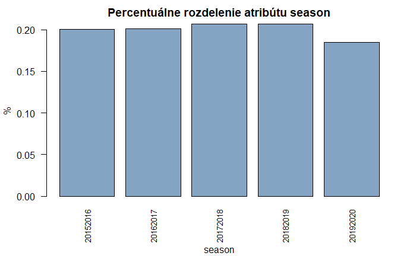

```r
barplot(prop.table(table(df$season)), las=2, cex.names=.8, col=rgb(0.2,0.4,0.6,0.6), ylab="%", xlab="", main="Percentuálne rozdelenie atribútu season")
mtext(text = "season", side = 1,line = 4)
```

```r
table(df$season)
```

```
20152016 20162017 20172018 20182019 20192020
    1321     1323     1363     1360     1215
```

Z grafu môžeme vidieť, že dataset obsahuje 5 zvolených sezón. Rozdelenie počtu hier v sezónach je percentuálne približne rovnaké (+- 3%), pričom najmenej odohraných hier bolo v poslednej sezóne - pravdepodobne zapríčinené pandemickou situáciou. Posledná sezóna v datasete je ročník 2019/2020, keďže aktuálna sezóna 2020/2021 ešte nie je ukončená a teda nie je súčasťou datasetu.

### Atribút type

**charakteristika:** atribút reprezentuje typ odohraného zápasu. Nadobúda tri základné hodnoty:

- R - regular, označuje regulárne zápasy ktoré sa hrajú počas NHL sezóny
- P - playoff, označuje zápasy vyraďovacej časti NHL, hrajú sa na konci sezóny. Tejto časti sa zúčastňujú iba najlepšie tímy.
- A - ?, predpokladáme že exhibičné zápasy

```r
cat("Unikátne hodnoty: \n")
```

```
Unikátne hodnoty:
```

```r
unique(df$type)
```

```
[1] "R" "P" "A"
```

```r
cat(" \n Percentuálny podiel: \n")
```

```
 Percentuálny podiel:
```

```r
cat("R = ", (100/nrow(df))*nrow(df[df$type=='R']), "%\n")
```

```
R =  92.61623 %
```

```r
cat("P = ", (100/nrow(df))*nrow(df[df$type=='P']), "%\n")
```

```
P =  7.307809 %
```

```r
cat("A = ", (100/nrow(df))*nrow(df[df$type=='A']), "%\n")
```

```
A =  0.07596475 %
```

```r
cat(" \n Počet výskytov:")
```

```
 Počet výskytov:
```

```r
table(df$type)
```

```
   A    P    R
   5  481 6096
```

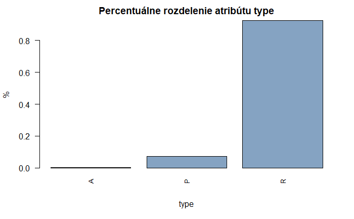

```r
barplot(prop.table(table(df$type)), las=2, cex.names=.8, col=rgb(0.2,0.4,0.6,0.6), ylab="%", xlab="type", main="Percentuálne rozdelenie atribútu type")
```

Z početností jednotlivých atribútov môžeme vidieť obrovskú prevahu zápasov regulárnej časti sezóny, čo aj zodpovedá skutočnosti. Použitie regulárnej sezóny na realizáciu trénovacieho datasetu a playoff na realizáciu testovacieho datatsetu nie je vhodné, pretože percentuálny podiel 92:7 nesedí s odporúčaným pomerom 70:30, alebo 80:20. Z tohoto dôvodu bude potrebné dodatočné prerozdelenie zápasov regulárnej sezóny tak, aby bol tento pomer splnený - bude riešené neskôr v práci. Hodnotu NA nemá žiaden atribút.

Hodnotu ‘A’ nadobúda len 5 záznamov, v žiadnom z nich sa nejedná o zápasy tímov NHL (abbreviation = NA).

```r
subset(df, type=='A')
```

| season | type | goals.away | goals.home | team_id.away | won.away | shots.away | hits.away | pim.away | powerPlayOpportunities.away | powerPlayGoals.away | faceOffWinPercentage.away | giveaways.away | takeaways.away | blocked.away | abbreviation.away | team_id.home | won.home | settled_in | shots.home | hits.home | pim.home | powerPlayOpportunities.home | powerPlayGoals.home | faceOffWinPercentage.home | giveaways.home | takeaways.home | blocked.home | abbreviation.home | save_percentage.home | … |
| --- | --- | --- | --- | --- | --- | --- | --- | --- | --- | --- | --- | --- | --- | --- | --- | --- | --- | --- | --- | --- | --- | --- | --- | --- | --- | --- | --- | --- | --- | --- |
| 20192020 | A | 5 | 9 | 88 | FALSE | 16 | 0 | 0 | 0 | 0 | 76.2 | 0 | 2 | 1 | NA | 87 | TRUE | tbc | 22 | 1 | 0 | 0 | 0 | 23.8 | 1 | 4 | 0 | NA | 0.6875 | … |
| 20192020 | A | 10 | 5 | 90 | TRUE | 28 | 0 | 0 | 0 | 0 | 35.0 | 1 | 6 | 1 | NA | 89 | FALSE | tbc | 17 | 0 | 0 | 0 | 0 | 65.0 | 1 | 8 | 1 | NA | 0.6429 | … |
| 20192020 | A | 4 | 5 | 87 | FALSE | 11 | 0 | 0 | 0 | 0 | 37.5 | 2 | 5 | 2 | NA | 90 | TRUE | tbc | 20 | 0 | 0 | 0 | 0 | 62.5 | 1 | 6 | 2 | NA | 0.6364 | … |
| 20182019 | A | 7 | 4 | 88 | TRUE | 26 | 0 | 0 | 0 | 0 | 56.2 | 2 | 6 | 1 | NA | 87 | FALSE | tbc | 20 | 0 | 0 | 0 | 0 | 43.8 | 1 | 8 | 0 | NA | 0.7308 | … |
| 20182019 | A | 10 | 5 | 88 | TRUE | 22 | 0 | 0 | 0 | 0 | 45.0 | 3 | 5 | 1 | NA | 89 | FALSE | tbc | 23 | 0 | 0 | 0 | 0 | 55.0 | 4 | 4 | 2 | NA | 0.5455 | … |

V zdroji datasetu nie je vysvetlené, čo hodnota “A” v atribúte type reprezentuje. Predpokladáme, že sa jedná o exhibičné zápasy, pretože atribúty tímov nie sú namapované na žiadne NHL tímy.

### Atribúty goals.home a goals.away

**charakteristika:** atribút reprezentuje počet gólov z pohľadu domáceho a hosťovského tímu.

Nejedná sa o spojitý atribút - počet gólov môže nadobúdať iba celé hodnoty, jedná sa teda o diskrétny atribút. Už z podstaty atribútov **goals.gome** a **goals.away** vieme povedať, že sa nebude jednať o normálne rozdelenie, ale o distribúciu naklonenú vpravo (skewed right) - toto vieme poznamenať ešte pred vizualizáciou prostredníctvom histogramov. Taktiež bude pravdepodobne obsahovať vychýlené hodnoty, keďže sa zvyknú vyskytovať zápasy s nadmerným počtom gólov. Reálny priemer sa však zvykne pohybovať okolo hodnoty 2 góly pre tím - predpokladáme, že v datasete tomu tak bude tiež. Na začiatku si teda oba atribúty vizualizujeme prostredníctvom krabicových grafov a histogramov, aby sme mohli overiť naše iniciálne predpoklady.

```r
cat("Základná štatistika pre goals.home", "\n")
```

```
Základná štatistika pre goals.home
```

```r
summary(df$goals.home)
```

```
   Min. 1st Qu.  Median    Mean 3rd Qu.    Max.
   0.00    2.00    3.00    3.01    4.00   10.00
```

```r
cat("\n","Základná štatistika pre goals.away", "\n")
```

```
 Základná štatistika pre goals.away
```

```r
summary(df$goals.away)
```

```
   Min. 1st Qu.  Median    Mean 3rd Qu.    Max.
  0.000   2.000   3.000   2.749   4.000  10.000
```

Zo základnej štatistiky vieme povedať, že hodnoty sú koncentrované okolo počtu gólov 3 - konkrétne na základu priemeru a mediánu (menej citlivý na vychýlené hodnoty). Maximálny počet gólov pre domáce aj hosťujúce tímy je v oboch prípadoch 10. Podľa tretieho kvantilu = 4 vieme povedať, že hodnota 10 pôsobí vychýlene. Najvyššia koncentrácia vyzerá bude v pri hodnotách 2,3,4.

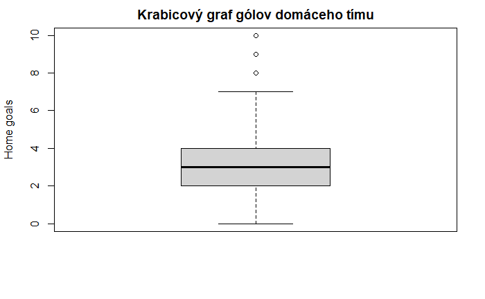

```r
boxplot(df$goals.home, ylab="Home goals", xlab="", main="Krabicový graf gólov domáceho tímu")
```

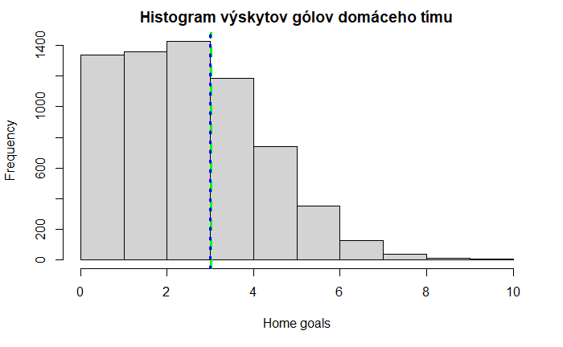

```r
hist(df$goals.home, xlab="Home goals", main="Histogram výskytov gólov domáceho tímu")
abline(v = c(mean(df$goals.home),  median(df$goals.home)), col=c("green", "blue"), lty=c(2,3), lwd=c(3,3))
```

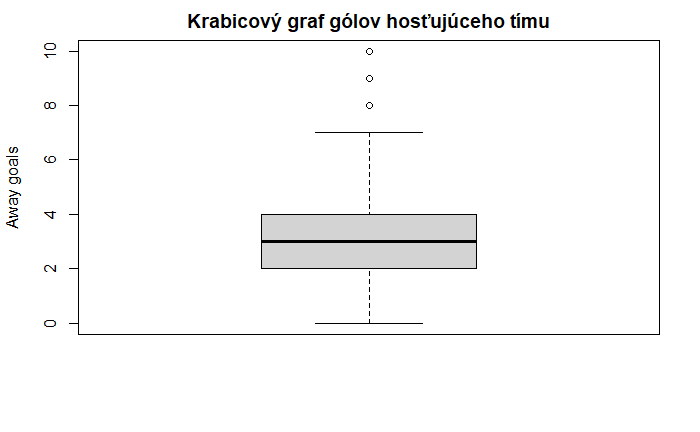

```r
boxplot(df$goals.away, ylab="Away goals", xlab="", main="Krabicový graf gólov hosťujúceho tímu")
```

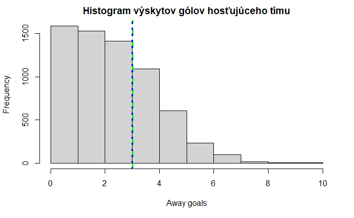

```r
hist(df$goals.away, xlab="Away goals", main="Histogram výskytov gólov hosťujúceho tímu")
abline(v = c(mean(df$goals.home),  median(df$goals.home)), col=c("green", "blue"), lty=c(2,3), lwd=c(3,3))
```

Dodatočne ešte overíme, či neexistujú chýbajúce hodnoty týchto atribútov v niektorých záznamoch:

```r
cat("Počet záznamov kde je goals.home NA", nrow(subset(df, is.na(goals.home)==TRUE)), '\n')
```

```
Počet záznamov kde je goals.home NA 0
```

```r
cat("Počet záznamov kde je goals.away NA",nrow(subset(df, is.na(goals.away)==TRUE)),'\n')
```

```
Počet záznamov kde je goals.away NA 0
```

Ani jeden záznam nenadobúda pri atribútoch goals.home a goals.away NA hodnoty, preto nebude potrebné riešiť voľbu stratégie dopĺňania týchto hodnôt.

```r
subset(df, goals.home >= 8)
```

| season | type | goals.away | goals.home | team_id.away | won.away | shots.away | hits.away | pim.away | powerPlayOpportunities.away | powerPlayGoals.away | faceOffWinPercentage.away | giveaways.away | takeaways.away | blocked.away | abbreviation.away | team_id.home | won.home | settled_in | shots.home | hits.home | pim.home | powerPlayOpportunities.home | powerPlayGoals.home | faceOffWinPercentage.home | giveaways.home | takeaways.home | blocked.home | abbreviation.home | save_percentage.home | … |
| --- | --- | --- | --- | --- | --- | --- | --- | --- | --- | --- | --- | --- | --- | --- | --- | --- | --- | --- | --- | --- | --- | --- | --- | --- | --- | --- | --- | --- | --- | --- |
| 20172018 | R | 3 | 8 | 22 | FALSE | 29 | 32 | 11 | 1 | 0 | 47.5 | 1 | 9 | 16 | EDM | 19 | TRUE | REG | 40 | 11 | 7 | 3 | 1 | 52.5 | 2 | 18 | 8 | STL | 0.8966 | … |
| 20152016 | R | 1 | 8 | 22 | FALSE | 31 | 18 | 34 | 1 | 0 | 47.7 | 10 | 6 | 11 | EDM | 2 | TRUE | REG | 31 | 21 | 18 | 4 | 2 | 52.3 | 11 | 5 | 8 | NYI | 0.9677 | … |
| 20172018 | R | 4 | 8 | 5 | FALSE | 26 | 28 | 19 | 4 | 0 | 46.9 | 14 | 9 | 25 | PIT | 6 | TRUE | REG | 38 | 30 | 17 | 5 | 3 | 53.1 | 8 | 9 | 5 | BOS | 0.8462 | … |
| 20172018 | R | 3 | 8 | 24 | FALSE | 34 | 21 | 11 | 3 | 0 | 62.3 | 14 | 4 | 3 | ANA | 13 | TRUE | REG | 22 | 12 | 11 | 3 | 1 | 37.7 | 20 | 9 | 11 | FLA | 0.9118 | … |
| 20172018 | R | 1 | 10 | 17 | FALSE | 23 | 36 | 6 | 1 | 0 | 49.2 | 8 | 7 | 15 | DET | 8 | TRUE | REG | 34 | 16 | 4 | 2 | 1 | 50.8 | 13 | 9 | 14 | MTL | 0.9565 | … |
| 20162017 | R | 4 | 8 | 19 | FALSE | 37 | 11 | 12 | 5 | 4 | 47.5 | 3 | 2 | 12 | STL | 29 | TRUE | REG | 30 | 20 | 18 | 2 | 1 | 52.5 | 6 | 7 | 13 | CBJ | 0.8919 | … |
| 20162017 | R | 7 | 8 | 15 | FALSE | 28 | 41 | 4 | 4 | 1 | 50.0 | 3 | 5 | 16 | WSH | 5 | TRUE | OT | 37 | 33 | 10 | 1 | 1 | 50.0 | 8 | 5 | 16 | PIT | 0.7500 | … |
| 20162017 | R | 2 | 8 | 25 | FALSE | 30 | 18 | 52 | 5 | 2 | 49.2 | 10 | 5 | 19 | DAL | 52 | TRUE | REG | 31 | 23 | 42 | 5 | 3 | 50.8 | 15 | 9 | 16 | WPG | 0.9333 | … |
| 20162017 | R | 6 | 8 | 23 | FALSE | 34 | 15 | 11 | 2 | 0 | 50.0 | 3 | 9 | 15 | VAN | 12 | TRUE | REG | 36 | 11 | 9 | 3 | 2 | 50.0 | 16 | 10 | 13 | CAR | 0.8235 | … |
| 20162017 | R | 1 | 10 | 21 | FALSE | 16 | 35 | 8 | 3 | 0 | 29.8 | 15 | 4 | 13 | COL | 8 | TRUE | REG | 36 | 11 | 10 | 2 | 1 | 70.2 | 10 | 7 | 10 | MTL | 0.9375 | … |

[output cut: 38 more lines]

```r
cat("Počet vychýlených hodnôt atribútu goals.home podľa krabicového grafu:", nrow(subset(df, goals.home >= 8)))
```

```
Počet vychýlených hodnôt atribútu goals.home podľa krabicového grafu: 48
```

```r
subset(df, goals.away >= 8)
```

| season | type | goals.away | goals.home | team_id.away | won.away | shots.away | hits.away | pim.away | powerPlayOpportunities.away | powerPlayGoals.away | faceOffWinPercentage.away | giveaways.away | takeaways.away | blocked.away | abbreviation.away | team_id.home | won.home | settled_in | shots.home | hits.home | pim.home | powerPlayOpportunities.home | powerPlayGoals.home | faceOffWinPercentage.home | giveaways.home | takeaways.home | blocked.home | abbreviation.home | save_percentage.home | … |
| --- | --- | --- | --- | --- | --- | --- | --- | --- | --- | --- | --- | --- | --- | --- | --- | --- | --- | --- | --- | --- | --- | --- | --- | --- | --- | --- | --- | --- | --- | --- |
| 20172018 | R | 8 | 3 | 1 | TRUE | 28 | 34 | 10 | 2 | 1 | 51.5 | 9 | 2 | 26 | NJD | 54 | FALSE | REG | 42 | 28 | 4 | 5 | 2 | 48.5 | 10 | 10 | 9 | VGK | 0.7143 | … |
| 20162017 | R | 8 | 4 | 12 | TRUE | 33 | 20 | 6 | 2 | 0 | 55.6 | 3 | 5 | 9 | CAR | 2 | FALSE | REG | 27 | 30 | 6 | 2 | 0 | 44.4 | 14 | 4 | 12 | NYI | 0.7576 | … |
| 20172018 | R | 8 | 3 | 8 | TRUE | 29 | 24 | 21 | 4 | 1 | 44.6 | 7 | 3 | 19 | MTL | 9 | FALSE | REG | 28 | 31 | 29 | 5 | 2 | 55.4 | 7 | 7 | 17 | OTT | 0.7241 | … |
| 20172018 | R | 8 | 2 | 16 | TRUE | 43 | 14 | 10 | 6 | 4 | 50.7 | 11 | 7 | 19 | CHI | 9 | FALSE | REG | 27 | 24 | 14 | 4 | 0 | 49.3 | 13 | 10 | 17 | OTT | 0.8140 | … |
| 20152016 | R | 9 | 2 | 26 | TRUE | 57 | 30 | 16 | 3 | 3 | 60.0 | 10 | 13 | 17 | LAK | 6 | FALSE | REG | 37 | 30 | 16 | 3 | 1 | 40.0 | 6 | 6 | 10 | BOS | 0.8421 | … |
| 20172018 | R | 8 | 5 | 14 | TRUE | 38 | 8 | 11 | 5 | 2 | 49.3 | 17 | 12 | 15 | TBL | 13 | FALSE | REG | 23 | 14 | 15 | 3 | 0 | 50.7 | 14 | 16 | 12 | FLA | 0.7895 | … |
| 20172018 | P | 8 | 5 | 5 | TRUE | 28 | 34 | 10 | 1 | 0 | 46.2 | 7 | 7 | 22 | PIT | 4 | FALSE | REG | 26 | 37 | 6 | 3 | 0 | 53.8 | 13 | 3 | 14 | PHI | 0.7143 | … |
| 20192020 | R | 8 | 1 | 6 | TRUE | 24 | 19 | 6 | 2 | 2 | 50.0 | 24 | 9 | 16 | BOS | 8 | FALSE | REG | 37 | 34 | 6 | 2 | 0 | 50.0 | 18 | 11 | 12 | MTL | 0.6667 | … |
| 20192020 | R | 8 | 3 | 18 | TRUE | 24 | 24 | 18 | 5 | 2 | 47.7 | 14 | 2 | 23 | NSH | 2 | FALSE | REG | 30 | 34 | 34 | 2 | 1 | 52.3 | 18 | 2 | 14 | NYI | 0.6667 | … |
| 20192020 | R | 8 | 5 | 30 | TRUE | 33 | 22 | 12 | 2 | 0 | 39.7 | 9 | 3 | 22 | MIN | 53 | FALSE | REG | 40 | 20 | 8 | 4 | 2 | 60.3 | 5 | 5 | 10 | ARI | 0.7576 | … |

[output cut: 13 more lines]

```r
cat("Počet vychýlených hodnôt atribútu goals.away podľa krabicového grafu:", nrow(subset(df, goals.away >= 8)))
```

```
Počet vychýlených hodnôt atribútu goals.away podľa krabicového grafu: 23
```

Z výpisov vidíme, že počet zápasov v ktorých domáci tím strelil 8 a viac gólov je 48, zatiaľ čo počet zápasov v ktorých vonkajší tím strelil 8 a viac gólov je 23 - tento fakt len podporuje hypotézu, že domáce prostredie má reálny vplyv na množstvo strelených gólov. Krabicový graf tieto hodnoty označuje ako vychýlené, no keďže obsahujú dôležité informácie a jedná sa o reálne hodnoty (nie napr. chyby senzorov), tieto hodnoty nie je vhodné odstraňovať a ani normovať, resp. zrážat na nižšiu hodnotu.